# Problem Set 5: Using Pandas

### 3. Answering questions with the data

Now that we have command of our imported data sets, we're ready to begin our analysis. In this example, we are going to explore the wanderings of George the elephant. In particular, we want to use the tracking data to see how often George travels near a particular [imaginary] village located at latitude 6.32°N, 7.62°W.

**Tip**: Don't forget that longitude values west of prime meridian are negative...

► Q3.1 If the 'Y' column represents latitude, what's the southern most location George has been seen?

```python
#Display the southern most location of the "George" subset
```

```
6.2032
```

► Q3.2 Somehow demonstrate that George been seen north of 6.23°N **28** times. (In other words, show how many records meet the criteria...)

```
28
```

► Q3.3 How many times has George been seen north of 6.23°N *and* west of 7.62°W?

```
18
```

► Q3.4 What's the *earliest* "Fixtime" date George has been seen 6.23°N and west of 7.62°W?

```
Timestamp('2017-04-10 04:12:32')
```

## A cool plot!

If we set the index of our table to a time column, then plot the XY coordinates, we can visualize the track of our elephant...

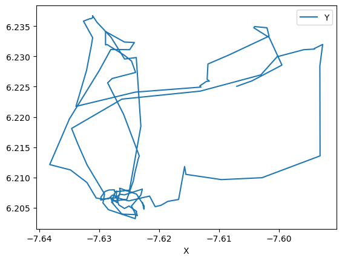

```python
#Plot the path of George!
dfGeorge.set_index('Fixtime').plot(x='X',y='Y');
```

See if you can to it with another elephant. You'll have to subset the table for a different individual - we'll choose "Cami" - then repeat the steps above...

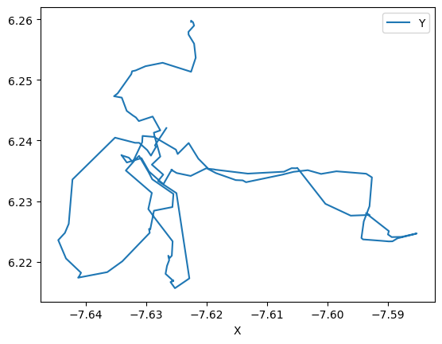

```python
#Plot the path of Cami
```

### 4. Grouping/aggregating data

Now we want to generate some quick movement stats on each individual from our dataset. First, we'll use Panda's `value_counts()` to generate a quick list of how many times each individual has been tracked. Then we'll use Panda's `groupby` function to create a grouped object from which we can easily generate aggeregate statistics like the mean X and Y coordinates taken from all records for a given individual.

► Q4.1 Use the `value_counts()` function to list how many records exist for each elephant.

```python
df['MovDataID'].value_counts()
```

```
MovDataID
Blanche      146
Zamba        146
Sylvie       144
Omar         144
Laura        143
Cami         139
DjeDje       138
Dave         138
Frank        134
Yves         134
Tapa         134
Claudine     134
George       132
Mahmahdou    132
Anika         35
Marie         34
Name: count, dtype: int64
```

► Q4.2 Group the dataframe of all elephants on the `MovDataID` attribute into a "groupBy" object called `grpName`.

```python
grpName = df.groupby('MovDataID')
```

► Q4.3 Apply the appropriate aggregate function to the `grpName` object to report the median X and Y coordinate for each elephant.  
*Partial credit will be given if include more than just the X and Y columns...*

```python
#Report the mean X and Y values for each elephant using the grpName object created above
grpName[['X','Y']].median()
```

| MovDataID | X | Y |
| --- | --- | --- |
| Anika | -7.894817 | 6.004683 |
| Blanche | -7.871358 | 5.861492 |
| Cami | -7.625967 | 6.234633 |
| Claudine | -7.631233 | 6.168733 |
| Dave | -7.665100 | 6.206167 |
| DjeDje | -8.027500 | 6.265792 |
| Frank | -7.708358 | 6.113575 |
| George | -7.625758 | 6.210975 |
| Laura | -7.709083 | 6.172267 |
| Mahmahdou | -7.683300 | 6.280983 |
| Marie | -7.836750 | 5.869792 |
| Omar | -7.754417 | 6.216633 |
| Sylvie | -7.732183 | 6.331867 |
| Tapa | -7.709117 | 6.137833 |
| Yves | -7.667825 | 6.131133 |
| Zamba | -7.671250 | 6.117942 |

### Demonstrations: Transforming/pivoting data

*►This portion is ungraded◄*  
We may also want to transform our data. Below are some examples of how that is done using Pandas.

In this example, we first want to examine how many tracking records occur across the hours of the day. To do this, we first need to create a new column listing just the hour from the `Fixtime` timestamp. Pandas has a function to do this: `.dt.hour`.

```python
#Add an "hour" column to the data
df['Hour'] = df['Fixtime'].dt.hour
#Have a look at the result
df.head()
```

|  | MovDataID | CalcID | StartDate | EndDate | Fixtime | X | Y | Z | Hour |
| --- | --- | --- | --- | --- | --- | --- | --- | --- | --- |
| 0 | Cami | 587 | 2017-04-09 07:33:40 | 2017-04-15 16:31:42 | 2017-04-09 08:14:57 | -7.626650 | 6.242050 | NaN | 8 |
| 1 | Cami | 587 | 2017-04-09 07:33:40 | 2017-04-15 16:31:42 | 2017-04-09 10:13:55 | -7.628533 | 6.239200 | NaN | 10 |
| 2 | Cami | 587 | 2017-04-09 07:33:40 | 2017-04-15 16:31:42 | 2017-04-09 11:14:33 | -7.628367 | 6.238933 | NaN | 11 |
| 3 | Cami | 587 | 2017-04-09 07:33:40 | 2017-04-15 16:31:42 | 2017-04-09 12:14:07 | -7.629200 | 6.237500 | NaN | 12 |
| 4 | Cami | 587 | 2017-04-09 07:33:40 | 2017-04-15 16:31:42 | 2017-04-09 13:13:56 | -7.629800 | 6.238400 | NaN | 13 |

With the hour field created, we can compute how may tracks were recorded at each hour (using `value_counts()`) and then plot these as a line plot. For this to work, we need to sort our value_counts result on the index, which is the hour recorded.

→ *Are there any trends in when elephants have been tracked?*  
→ *It's quite easy to repeat this analysis displaying track records across years. Could you do that?*

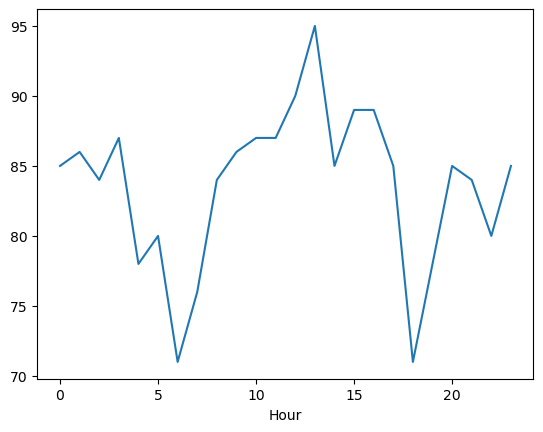

```python
#Plot the number of tracks recorded each out
(df['Hour']       # Extract just the hour records
  .value_counts() # Tally how many records of each hour
  .sort_index()   # Sort on the index (i.e. the hour)
  .plot()         # Create and display a line plot
);
```

Now we are going to move on to something a bit more sophisticated: we are going to add a new field to our tracking data frame that represents the distance each record is from a given location.

```python
#Create a function that calculates the distance from a coordinate
def get_dist(theX, theY, thePoint):
    #Extract the coordinates from the provided point into separate variables
    center_x, center_y = thePoint
    #Get distances along X and Y axes
    x_dist = theX - center_x
    y_dist = theY - center_y
    #Compute the distances between points
    the_dist = (x_dist ** 2 + y_dist ** 2) * 0.5
    #Return the distance
    return the_dist
```

Next we need a point (just a tuple of X and Y coordinates) from which to measure distances. We'll use the centroid of our data (mean X and Y values).

```python
#Get the centroid of all track records
the_centroid = (df['X'].mean(),df['Y'].mean())
the_centroid
```

```
(-7.877294295067264, 6.15885599715994)
```

And here is the syntax for applying our `get_dist()` function to the X and Y series in our dataframe to compute each record's distance from `the_centroid`.

```python
#Apply the function above to add a distance column
df['distance'] = get_dist(df['X'],df['Y'],the_centroid)
#Have a look
df.head()
```

|  | MovDataID | CalcID | StartDate | EndDate | Fixtime | X | Y | Z | Hour | distance |
| --- | --- | --- | --- | --- | --- | --- | --- | --- | --- | --- |
| 0 | Cami | 587 | 2017-04-09 07:33:40 | 2017-04-15 16:31:42 | 2017-04-09 08:14:57 | -7.626650 | 6.242050 | NaN | 8 | 0.034872 |
| 1 | Cami | 587 | 2017-04-09 07:33:40 | 2017-04-15 16:31:42 | 2017-04-09 10:13:55 | -7.628533 | 6.239200 | NaN | 10 | 0.034169 |
| 2 | Cami | 587 | 2017-04-09 07:33:40 | 2017-04-15 16:31:42 | 2017-04-09 11:14:33 | -7.628367 | 6.238933 | NaN | 11 | 0.034189 |
| 3 | Cami | 587 | 2017-04-09 07:33:40 | 2017-04-15 16:31:42 | 2017-04-09 12:14:07 | -7.629200 | 6.237500 | NaN | 12 | 0.033868 |
| 4 | Cami | 587 | 2017-04-09 07:33:40 | 2017-04-15 16:31:42 | 2017-04-09 13:13:56 | -7.629800 | 6.238400 | NaN | 13 | 0.033790 |

To do this we want to transform or "pivot" our data such that:

- Each each unique`MovDataID` value becomes a row
- Each unique `Hour` value becomes a column
- The table shows mean distance values for each combination of elephant/hour of day

We'll do this and then add some styling such that dark blue values indicate animals furthest from the centroid.

```python
#Pivot data
df.pivot_table(
    index='MovDataID', # <- The index becomes the row name
    columns='Hour',    # <- Each unique value in the Hour column become a new separate column
    values=['distance'],      # <- The value assigned to each species/hour combination is taken from the "X" column
    aggfunc='mean'   # <- If more than one species/hour value exists, we will insert the median value
              ).style.background_gradient(cmap = 'YlGnBu') #Style the output
```

| Hour MovDataID | distance 0 | distance 1 | distance 2 | distance 3 | distance 4 | distance 5 | distance 6 | distance 7 | distance 8 | distance 9 | distance 10 | distance 11 | distance 12 | distance 13 | distance 14 | distance 15 | distance 16 | distance 17 | distance 18 | distance 19 | distance 20 | distance 21 | distance 22 | distance 23 |
| --- | --- | --- | --- | --- | --- | --- | --- | --- | --- | --- | --- | --- | --- | --- | --- | --- | --- | --- | --- | --- | --- | --- | --- | --- |
| Anika | 0.013238 | nan | nan | 0.011058 | 0.014051 | nan | nan | 0.010882 | 0.014839 | nan | nan | 0.011660 | 0.013748 | nan | nan | 0.010518 | 0.013247 | nan | nan | 0.010282 | 0.013277 | nan | nan | 0.010924 |
| Blanche | 0.045959 | 0.044909 | 0.045882 | 0.045766 | 0.045700 | 0.045615 | 0.045640 | 7.298096 | 0.043922 | 0.044262 | 0.044125 | 0.043464 | 0.042343 | 0.042648 | 0.042308 | 0.043228 | 0.043711 | 0.044757 | 0.045383 | 0.045579 | 0.045414 | 0.045730 | 0.046187 | 0.046244 |
| Cami | 0.035077 | 0.035185 | 0.035401 | 0.035366 | 0.035777 | 0.036025 | 0.036932 | 0.036527 | 0.035518 | 0.034601 | 0.035980 | 0.035889 | 0.036252 | 0.037009 | 0.036325 | 0.036395 | 0.035146 | 0.035746 | 0.036412 | 0.035296 | 0.035341 | 0.035374 | 0.035295 | 0.035124 |
| Claudine | 0.028958 | 0.028978 | 0.029009 | 7.284461 | 0.029133 | 0.029067 | 0.029351 | 0.030818 | 0.031604 | 0.031092 | 0.030740 | 0.030738 | 0.030621 | 0.030633 | 0.030623 | 0.031732 | 0.030285 | 0.030549 | 0.032089 | 0.029922 | 0.030194 | 0.030398 | 0.029361 | 0.029016 |
| Dave | 0.026432 | 0.026131 | 0.025935 | 0.025847 | 0.025819 | 0.026138 | 0.025096 | 7.281276 | 6.244370 | 8.732697 | 0.024292 | 0.023649 | 0.023474 | 0.024253 | 0.025362 | 10.908792 | 0.024164 | 0.023369 | 7.280588 | 0.023290 | 0.025442 | 0.025530 | 0.025877 | 0.026274 |
| DjeDje | 0.017004 | 0.016382 | 0.016572 | 0.016491 | 0.016428 | 0.016319 | 0.016907 | 0.016134 | 0.015732 | 0.016180 | 0.015806 | 0.016051 | 0.015124 | 0.015788 | 0.016011 | 0.016048 | 0.016621 | 0.016571 | 0.017474 | 0.016614 | 7.275011 | 0.017780 | 0.016028 | 0.017160 |
| Frank | 0.015910 | 0.015741 | 0.015396 | 0.015051 | 0.014927 | 0.014030 | 0.014051 | 0.013622 | 0.013952 | 0.013340 | 0.013455 | 0.013390 | 0.013613 | 0.013518 | 0.015651 | 0.014412 | 0.014335 | 0.015717 | 0.015704 | 0.015538 | 0.015737 | 0.015685 | 0.015639 | 0.015904 |
| George | 0.033631 | 0.032593 | 0.034016 | 0.034815 | 0.035984 | 0.034382 | 0.036388 | 0.036413 | 0.034678 | 0.036088 | 0.034498 | 0.035835 | 0.034828 | 0.036663 | 0.034387 | 0.034734 | 0.034246 | 0.033035 | 0.032617 | 0.032627 | 0.032541 | 0.032865 | 0.032622 | 0.033147 |
| Laura | 0.014487 | 0.014424 | 0.014299 | 7.272207 | 0.014145 | 0.014098 | 0.013903 | 7.271815 | 7.272540 | 0.014454 | 14.530194 | 7.272316 | 0.014251 | 0.014207 | 0.014367 | 6.235466 | 0.014393 | 0.014471 | 0.014204 | 0.014251 | 0.014443 | 0.014632 | 0.014658 | 0.014568 |
| Mahmahdou | 0.027432 | 0.027199 | 0.027362 | 0.028441 | 0.027492 | 0.027561 | 0.027285 | 0.028201 | 6.248844 | 8.735662 | 0.028420 | 0.030341 | 0.027706 | 0.029416 | 0.029542 | 0.026545 | 0.028083 | 0.030600 | 0.026044 | 0.030579 | 0.029253 | 0.028573 | 0.028197 | 0.027707 |
| Marie | nan | 0.043860 | nan | nan | nan | 0.043899 | nan | nan | nan | 8.746202 | nan | nan | nan | 0.044444 | nan | nan | nan | 0.044700 | nan | nan | nan | 0.043473 | nan | nan |
| Omar | 7.267820 | 0.009155 | 0.009155 | 0.009244 | 0.009322 | 0.009533 | 0.009743 | 7.268262 | 0.009878 | 0.009873 | 6.231392 | 0.009678 | 0.009705 | 0.009687 | 0.009397 | 6.231224 | 8.720060 | 7.268417 | 0.010240 | 0.010248 | 0.010066 | 0.009738 | 0.009344 | 0.009148 |
| Sylvie | 0.028166 | 0.028332 | 0.028410 | 0.028429 | 0.027657 | 0.027463 | 0.025541 | 0.023691 | 7.279292 | 0.023178 | 0.022454 | 0.022186 | 0.022659 | 0.022498 | 6.242445 | 0.022436 | 7.279287 | 0.023411 | 0.024226 | 0.025352 | 0.025956 | 0.026738 | 0.027354 | 0.027840 |
| Tapa | 0.013914 | 0.014064 | 0.014101 | 0.014051 | 0.013837 | 0.013418 | 0.012858 | 0.013028 | 0.012606 | 0.012580 | 0.012608 | 0.013103 | 0.013771 | 0.013086 | 0.013958 | 0.013673 | 0.012802 | 0.013900 | 0.013880 | 0.013354 | 0.013948 | 0.014024 | 0.013966 | 0.013901 |
| Yves | 0.021338 | 0.021749 | 0.022090 | 0.022437 | 0.022706 | 0.022607 | 0.022451 | 0.022724 | 0.023056 | 0.022779 | 0.022432 | 0.022364 | 0.022682 | 0.022574 | 0.022645 | 0.022226 | 0.021916 | 0.022218 | 0.020715 | 0.020570 | 0.020505 | 0.020609 | 0.020660 | 0.020957 |
| Zamba | 14.534592 | 0.022195 | 0.022073 | 0.022074 | 0.022251 | 0.022036 | 0.021994 | 0.022410 | 0.021636 | 0.021317 | 7.278447 | 0.022131 | 0.022268 | 0.021754 | 0.022349 | 6.242183 | 6.241515 | 0.021531 | 0.020775 | 0.021390 | 0.021508 | 0.021858 | 0.021842 | 0.021788 |

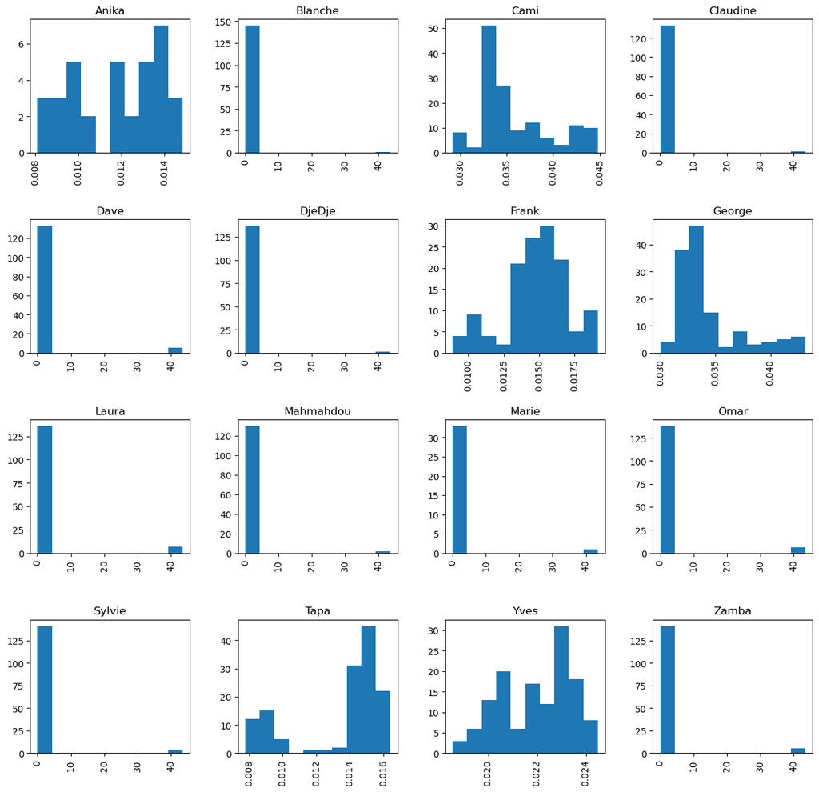

```python
#Or, using the untransformed data, we can plot
df.hist(column='distance',by='MovDataID',figsize=(15,15));
```